# Master en Big Data. Fundamentos Matemáticos del Análisis de Datos (FMAD).

Tarea 1

Ana Blasi Sanchiz

Curso 2021-22. Última actualización: 2021-09-17

# Instrucciones preliminares

- Empieza abriendo el proyecto de RStudio correspondiente a tu repositorio personal de la asignatura.
- En todas las tareas tendrás que repetir un proceso como el descrito en la sección *Repite los pasos Creando un fichero Rmarkdown para esta práctica* de la *Práctica00*. Puedes releer la sección *Practicando la entrega de las Tareas* de esa misma práctica para recordar el procedimiento de entrega.

# PRACTICA 0

- Si no has hecho los *Ejercicios* de la *Práctica00* (págs. 12 y 13) hazlos ahora y añádelos a esta tarea. Si ya los has hecho y entregado a través de GitHub no hace falta que hagas nada.

### Ejercicio 0.1

- Usando la función sample crea un vector dado_honesto con 100 números del 1 al 6. Haz una tabla de frecuencias absolutas (de dos maneras, con table y dplyr) y una tabla de frecuencias relativas.

Prerequisitos:

```r
library(dbplyr)
library(tidyverse)
```

Vector dado honesto

```r
dado_honesto = sample(1:6,100,replace = TRUE)
```

Frecuencia absoluta

```r
table(dado_honesto)
```

```
## dado_honesto
##  1  2  3  4  5  6
## 14 12  9 22 25 18
```

```r
tabla <- as.data.frame(dado_honesto)
```

Frecuencia absoluta utilizando la librería dplyr

```r
tabla %>%
  count(dado_honesto)
```

```
##   dado_honesto  n
## 1            1 14
## 2            2 12
## 3            3  9
## 4            4 22
## 5            5 25
## 6            6 18
```

Frecuencia relativa

```r
signif(prop.table(table(dado_honesto)), 2)
```

```
## dado_honesto
##    1    2    3    4    5    6
## 0.14 0.12 0.09 0.22 0.25 0.18
```

Frecuencia relativa utilizando la librería dplyr

```r
tabla %>%
    count(dado_honesto) %>%
    mutate(dado_honesto, relFreq = prop.table(n), n=NULL)
```

```
##   dado_honesto relFreq
## 1            1    0.14
## 2            2    0.12
## 3            3    0.09
## 4            4    0.22
## 5            5    0.25
## 6            6    0.18
```

### Ejercicio 0.2

- A continuación crea un nuevo vector dado_cargado de manera que la probabilidad de que el número elegido valga 6 sea el doble que la probabilidad de elegir cualquiera de los cinco números restantes. Lee la ayuda de sample si lo necesitas. De nuevo, haz tablas de frecuencias absolutas y relativas de este segundo vector.

Vector dado cargo

```r
dado_cargo = sample(1:6,100,replace = TRUE,prob= c(1/7, 1/7, 1/7, 1/7, 1/7, 2/7))
```

Frecuencia absoluta

```r
table(dado_cargo)
```

```
## dado_cargo
##  1  2  3  4  5  6
## 13 11 23 11 15 27
```

```r
tabla <- as.data.frame(dado_cargo)
```

Frecuencia absoluta utilizando la librería dplyr

```r
tabla %>%
  count(dado_cargo)
```

```
##   dado_cargo  n
## 1          1 13
## 2          2 11
## 3          3 23
## 4          4 11
## 5          5 15
## 6          6 27
```

Frecuencia relativa

```r
signif(prop.table(table(dado_cargo)), 2)
```

```
## dado_cargo
##    1    2    3    4    5    6
## 0.13 0.11 0.23 0.11 0.15 0.27
```

Frecuencia relativa utilizando la librería dplyr

```r
tabla %>%
    count(dado_cargo) %>%
    mutate(dado_cargo, relFreq = prop.table(n), n=NULL)
```

```
##   dado_cargo relFreq
## 1          1    0.13
## 2          2    0.11
## 3          3    0.23
## 4          4    0.11
## 5          5    0.15
## 6          6    0.27
```

### Ejercicio 0.3

- Utiliza las funciones rep y seq para crear tres vectores v1, v2 y v3 con estos elementos respectivamente:

```r
(v1 <- rep(seq(4,1),each=3))
```

```
##  [1] 4 4 4 3 3 3 2 2 2 1 1 1
```

```r
(v2 <- rep(seq(1,5), times = c(1,2,3,4,5)))
```

```
##  [1] 1 2 2 3 3 3 4 4 4 4 5 5 5 5 5
```

```r
(v3 <- rep(seq(1,4), times = 4))
```

```
##  [1] 1 2 3 4 1 2 3 4 1 2 3 4 1 2 3 4
```

### Ejercicio 0.4

- Utilizando la tabla mpg de la librería tidyverse crea una tabla mpg2 que:contenga las filas en las que la variable class toma el valor pickup y las columnas de la tabla original cuyos nombres empiezan por c. No se trata de que las selecciones a mano, por sus nombres.

```r
(mpg2 <- mpg %>%
   filter(mpg$class == 'pickup') %>%
    select(starts_with('c')))
```

```
## # A tibble: 33 × 3
##      cyl   cty class
##    <int> <int> <chr>
##  1     6    15 pickup
##  2     6    14 pickup
##  3     6    13 pickup
##  4     6    14 pickup
##  5     8    14 pickup
##  6     8    14 pickup
##  7     8     9 pickup
##  8     8    11 pickup
##  9     8    11 pickup
## 10     8    12 pickup
## # … with 23 more rows
```

### Ejercicio 0.5

- Descarga el fichero census.dta. Averigua de qué tipo de fichero se trata y usa la herramienta Import DataSet del panel Environment de RStudio para leer con R los datos de ese fichero. Asegúrate de copiar en esta práctica los dos primeros comandos que llevan a cabo la importación (excluye el comando View) y que descubrirás al usar esa herramienta. Después completa los siguientes apartados con esos datos y usando dplyr y ggplot:

Prerequisitos:

```r
library(ggplot2)
library(haven)
```

Poblaciones totales de las regiones censales

```r
census = read_dta(file = "./data/census.dta")
(poblaciones <- census %>%
  group_by(region) %>%
  summarise(pop = sum(pop)))
```

```
## # A tibble: 4 × 2
##        region      pop
##     <dbl+lbl>    <dbl>
## 1 1 [NE]      49135283
## 2 2 [N Cntrl] 58865670
## 3 3 [South]   74734029
## 4 4 [West]    43172490
```

Diagrama de las poblaciones totales según las diferentes regiones censales

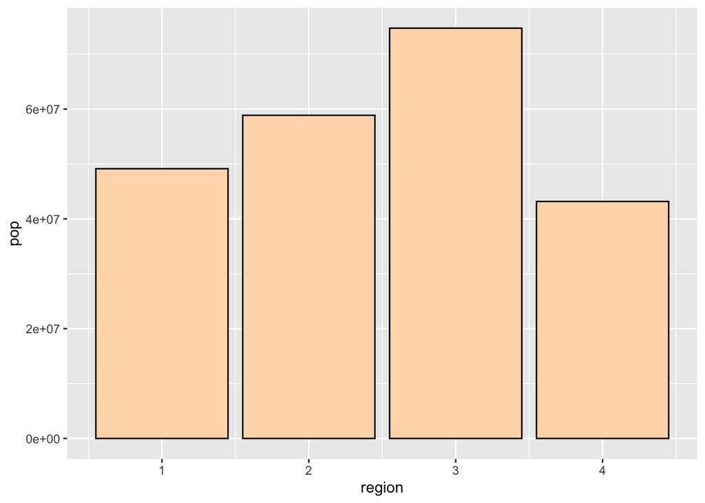

```r
ggplot(data = poblaciones) +
  geom_col(mapping = aes(x = region, y = pop),color="black",fill = "peachpuff")
```

Estados ordenados según la población

```r
census %>%
  select(state,pop) %>%
  arrange(desc(pop))
```

```
## # A tibble: 50 × 2
##    state             pop
##    <chr>           <dbl>
##  1 California   23667902
##  2 New York     17558072
##  3 Texas        14229191
##  4 Pennsylvania 11863895
##  5 Illinois     11426518
##  6 Ohio         10797630
##  7 Florida       9746324
##  8 Michigan      9262078
##  9 New Jersey    7364823
## 10 N. Carolina   5881766
## # … with 40 more rows
```

La tabla census con una nueva variable llamada tasa

```r
census %>%
  mutate(tasa=divorce/marriage)
```

```
## # A tibble: 50 × 13
##    state        region    pop poplt5 pop5_17 pop18p pop65p popurban medage  death
##    <chr>       <dbl+l>  <dbl>  <dbl>   <dbl>  <dbl>  <dbl>    <dbl>  <dbl>  <dbl>
##  1 Alabama     3 [Sou… 3.89e6 2.96e5  865836 2.73e6 4.40e5  2337713   29.3  35305
##  2 Alaska      4 [Wes… 4.02e5 3.89e4   91796 2.71e5 1.15e4   258567   26.1   1604
##  3 Arizona     4 [Wes… 2.72e6 2.14e5  577604 1.93e6 3.07e5  2278728   29.2  21226
##  4 Arkansas    3 [Sou… 2.29e6 1.76e5  495782 1.62e6 3.12e5  1179556   30.6  22676
##  5 California  4 [Wes… 2.37e7 1.71e6 4680558 1.73e7 2.41e6 21607606   29.9 186428
##  6 Colorado    4 [Wes… 2.89e6 2.16e5  592318 2.08e6 2.47e5  2329869   28.6  18925
##  7 Connecticut 1 [NE]  3.11e6 1.85e5  637731 2.28e6 3.65e5  2449774   32    26005
##  8 Delaware    3 [Sou… 5.94e5 4.12e4  125444 4.28e5 5.92e4   419819   29.8   5123
##  9 Florida     3 [Sou… 9.75e6 5.70e5 1789412 7.39e6 1.69e6  8212385   34.7 104190
## 10 Georgia     3 [Sou… 5.46e6 4.15e5 1231195 3.82e6 5.17e5  3409081   28.7  44230
## # … with 40 more rows, and 3 more variables: marriage <dbl>, divorce <dbl>,
## #   tasa <dbl>
```

10 primeros valores de la tabla donde se observa los estados más envejecidos

```r
(tabla <- census %>%
  select(state,medage) %>%
  mutate(prop=(census$pop65p)/(census$pop)) %>%
  arrange(desc(medage)) %>%
  head(10))
```

```
## # A tibble: 10 × 3
##    state         medage  prop
##    <chr>          <dbl> <dbl>
##  1 Florida         34.7 0.173
##  2 New Jersey      32.2 0.117
##  3 Pennsylvania    32.1 0.129
##  4 Connecticut     32   0.117
##  5 New York        31.9 0.123
##  6 Rhode Island    31.8 0.134
##  7 Massachusetts   31.2 0.127
##  8 Missouri        30.9 0.132
##  9 Arkansas        30.6 0.137
## 10 Maine           30.4 0.125
```

Histograma con los valores de la variable medage y con la curva de densidad de la variable superpuesta

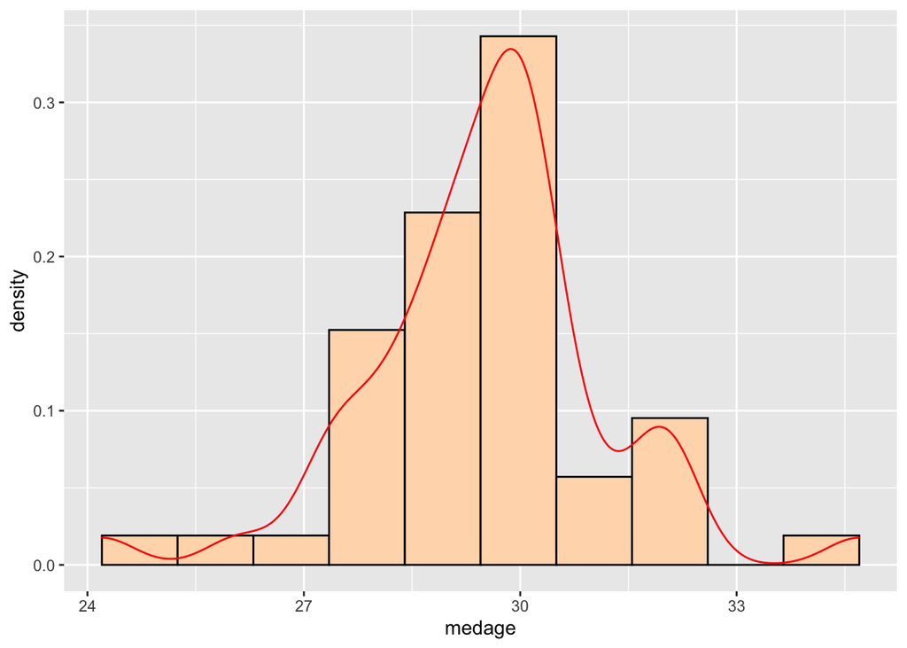

```r
cortes <- seq(min(census$medage), max(census$medage), length.out=11)
ggplot(data=census, aes(x = medage)) + geom_histogram(aes(y=stat(density)), breaks = cortes, fill = "peachpuff", color="black") + geom_density(color="red")
```

# TAREA 1

## Ejercicio 1. Análisis exploratorio de un conjunto de datos y operaciones con dplyr.

- Vamos a utilizar el conjunto de datos contenido en el fichero (es un enlace):  
  cholesterol.csv  
  Los datos proceden de un estudio realizado en la *University of Virginia School of Medicine* que investiga la prevalencia de la obesidad, la diabetes y otros factores de riesgo cardiovascular. Se puede encontrar más información sobre el fichero en este enlace:  
  https://biostat.app.vumc.org/wiki/pub/Main/DataSets/diabetes.html
- Carga el conjunto de datos en un data.frame de R llamado `chlstrl`.

```
Rows: 403 Columns: 7
```

- Empezaremos por información básica sobre el conjunto de datos. Cuántas observaciones contiene, cuáles son las variables y de qué tipos,…

```r
str(chlstrl)
```

```
## spec_tbl_df [403 × 7] (S3: spec_tbl_df/tbl_df/tbl/data.frame)
##  $ chol  : num [1:403] 203 165 228 78 249 248 195 227 177 263 ...
##  $ age   : num [1:403] 46 29 58 67 64 34 30 37 45 55 ...
##  $ gender: chr [1:403] "female" "female" "female" "male" ...
##  $ height: num [1:403] 62 64 61 67 68 71 69 59 69 63 ...
##  $ weight: num [1:403] 121 218 256 119 183 190 191 170 166 202 ...
##  $ waist : num [1:403] 29 46 49 33 44 36 46 34 34 45 ...
##  $ hip   : num [1:403] 38 48 57 38 41 42 49 39 40 50 ...
##  - attr(*, "spec")=
##   .. cols(
##   ..   chol = col_double(),
##   ..   age = col_double(),
##   ..   gender = col_character(),
##   ..   height = col_double(),
##   ..   weight = col_double(),
##   ..   waist = col_double(),
##   ..   hip = col_double()
##   .. )
##  - attr(*, "problems")=<externalptr>
```

- Asegúrate de comprobar si hay datos ausentes y localízalos en la tabla.

```r
#Numero de datos ausentes
sum(is.na(chlstrl))
```

```
## [1] 11
```

```r
#Localización de los datos ausentes
apply(is.na(chlstrl),2, which)
```

```
## $chol
## [1] 28
##
## $age
## integer(0)
##
## $gender
## integer(0)
##
## $height
## [1]  64  87 196 232 318
##
## $weight
## [1] 162
##
## $waist
## [1] 337 394
##
## $hip
## [1] 337 394
```

- El análisis exploratorio (numérico y gráfico) debe cubrir todos los tipos de variable de la tabla. Es decir, que al menos debes estudiar una variable por cada tipo de variable presente en la tabla. El análisis debe contener, al menos:
  - Para las variables cuantitativas (continuas o discretas).  
    Resumen numérico básico.  
    Gráficas (las adecuadas, a ser posible más de un tipo de gráfico).
  - Variables categóricas (factores).  
    Tablas de frecuencia (absolutas y relativas).  
    Gráficas (diagrama de barras).

Tipo de variable de la tabla

```r
chlstrl %>%
  sapply(class)
```

```
##        chol         age      gender      height      weight       waist
##   "numeric"   "numeric" "character"   "numeric"   "numeric"   "numeric"
##         hip
##   "numeric"
```

- Infromación sobre variables cuantitativas

Estudio sobre cada tipo de variable que hay en la tabla

```r
summary(chlstrl)
```

```
##       chol            age           gender              height
##  Min.   : 78.0   Min.   :19.00   Length:403         Min.   :52.00
##  1st Qu.:179.0   1st Qu.:34.00   Class :character   1st Qu.:63.00
##  Median :204.0   Median :45.00   Mode  :character   Median :66.00
##  Mean   :207.8   Mean   :46.85                      Mean   :66.02
##  3rd Qu.:230.0   3rd Qu.:60.00                      3rd Qu.:69.00
##  Max.   :443.0   Max.   :92.00                      Max.   :76.00
##  NA's   :1                                          NA's   :5
##      weight          waist           hip
##  Min.   : 99.0   Min.   :26.0   Min.   :30.00
##  1st Qu.:151.0   1st Qu.:33.0   1st Qu.:39.00
##  Median :172.5   Median :37.0   Median :42.00
##  Mean   :177.6   Mean   :37.9   Mean   :43.04
##  3rd Qu.:200.0   3rd Qu.:41.0   3rd Qu.:46.00
##  Max.   :325.0   Max.   :56.0   Max.   :64.00
##  NA's   :1       NA's   :2      NA's   :2
```

Histograma de densidad de los datos de cholesterol

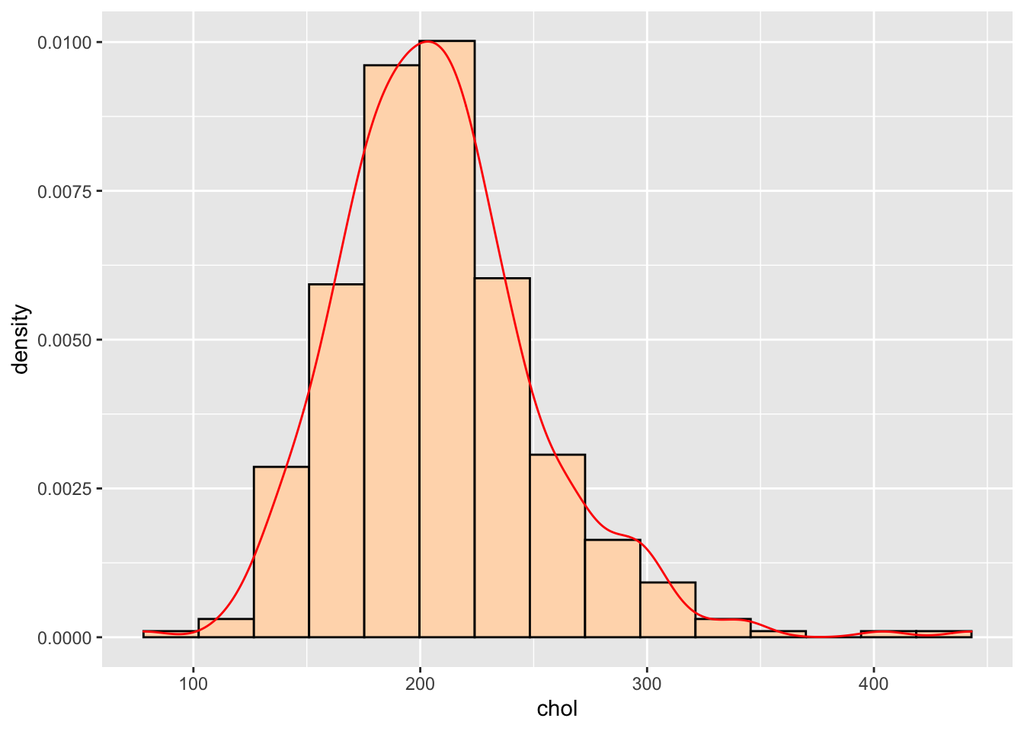

```r
cortes = seq(min(chlstrl$chol, na.rm = TRUE),max(chlstrl$chol, na.rm = TRUE),length.out = 16)
ggplot(data = chlstrl, mapping = aes(chol)) +
  geom_histogram(aes(y = stat(density)), breaks = cortes, fill = "peachpuff", color = "black") +
  geom_density(color = "red")
```

Boxpolt de los datos del cholesterol

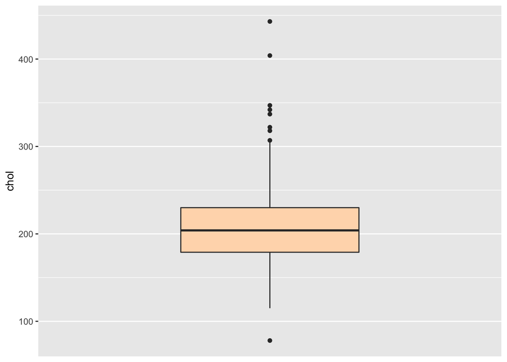

```r
ggplot(data = chlstrl) +
  scale_x_discrete(breaks = c()) +
  geom_boxplot(mapping = aes(y = chol), fill = "peachpuff")
```

Histograma de frecuencia de los datos de edad

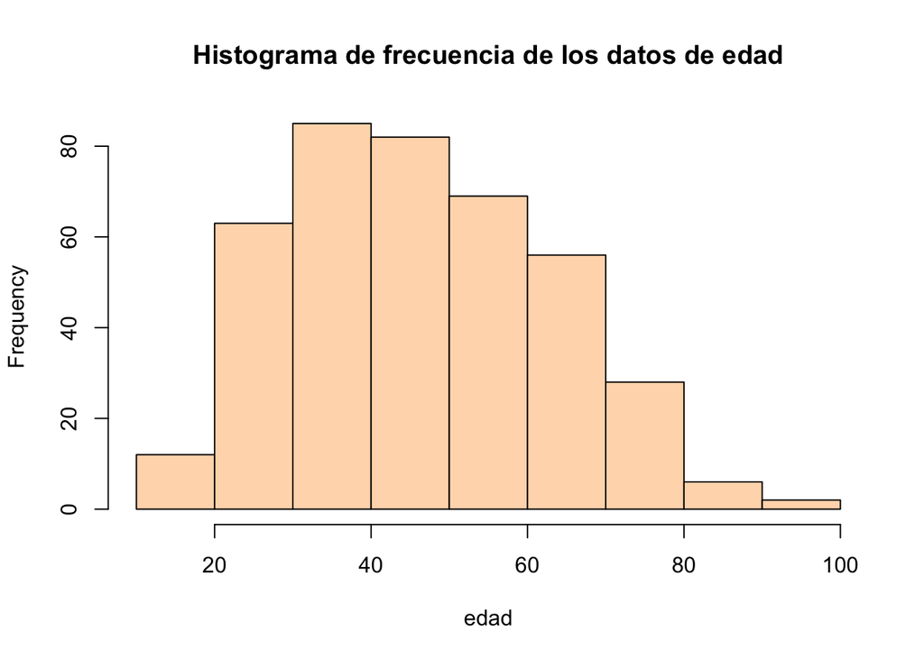

```r
edad <- chlstrl$age
hist(edad, col= 'peachpuff',main ='Histograma de frecuencia de los datos de edad')
```

Histograma de frecuencia de los datos de altura

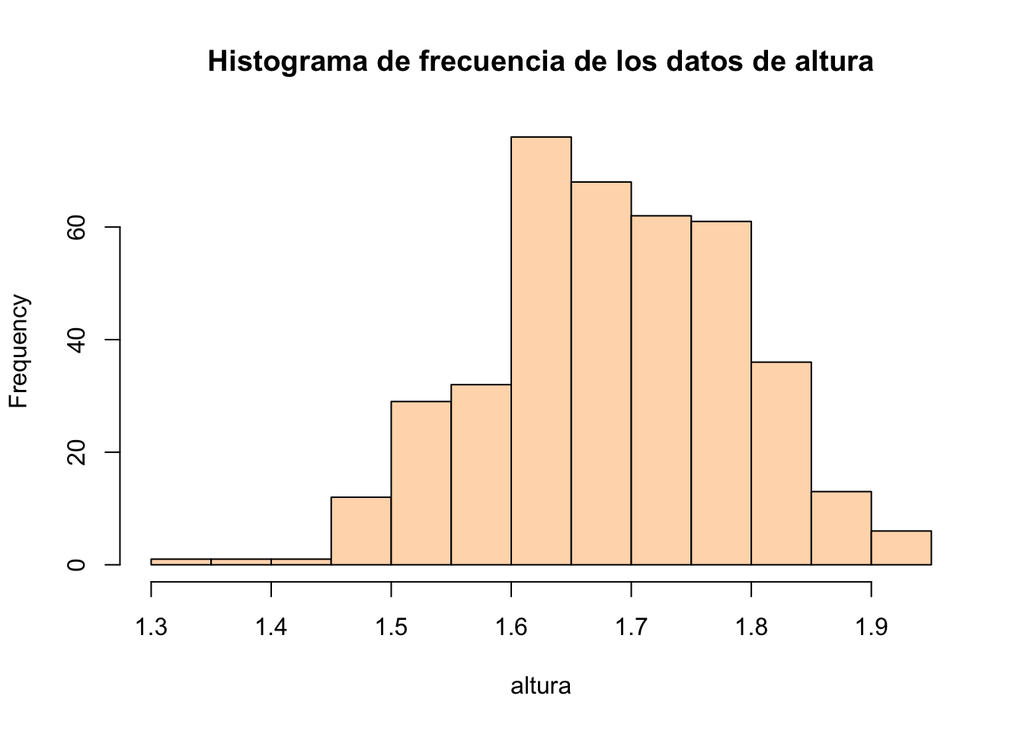

```r
altura <- chlstrl$height*0.0254
hist(altura, col= 'peachpuff',main="Histograma de frecuencia de los datos de altura")
```

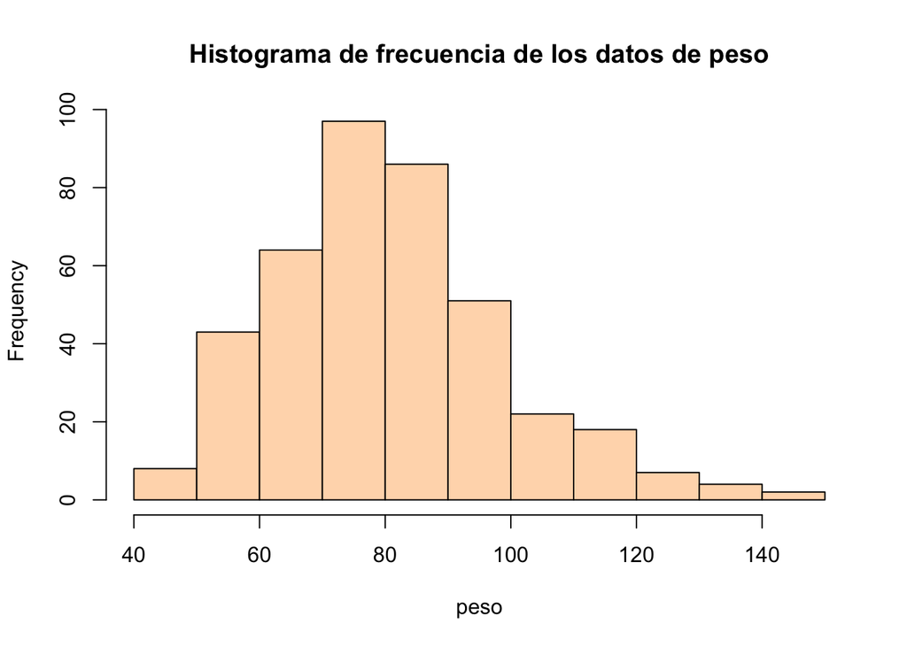

```r
peso <- chlstrl$weight*0.454
hist(peso, col= 'peachpuff',main="Histograma de frecuencia de los datos de peso")
```

Boxplot de los datos de medidas de cintura

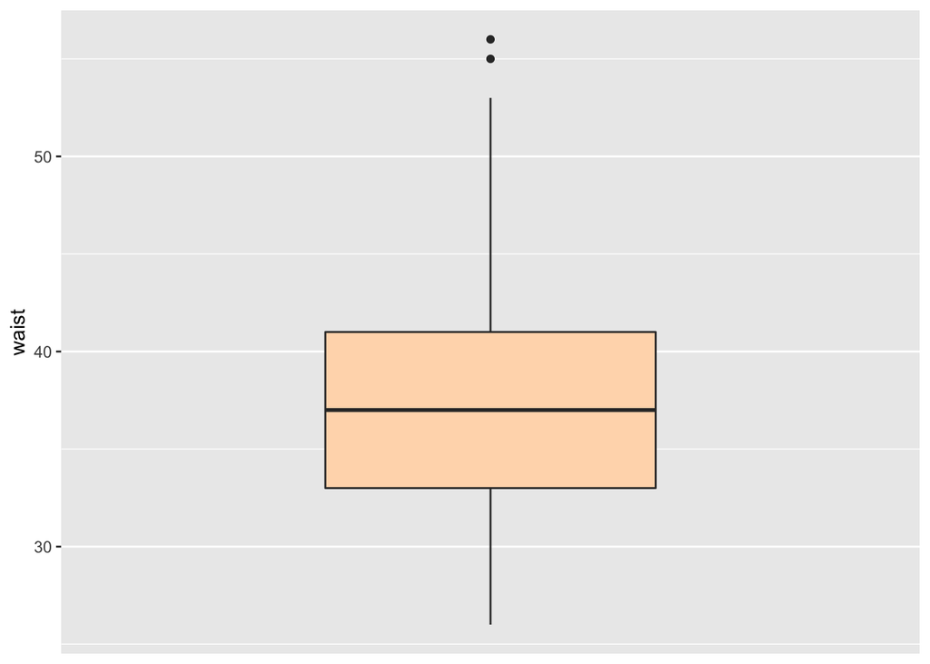

```r
ggplot(data = chlstrl) +
  scale_x_discrete(breaks = c()) +
  geom_boxplot(mapping = aes(y = waist), fill = "peachpuff")
```

Boxplot de los datos de medidas de cadera

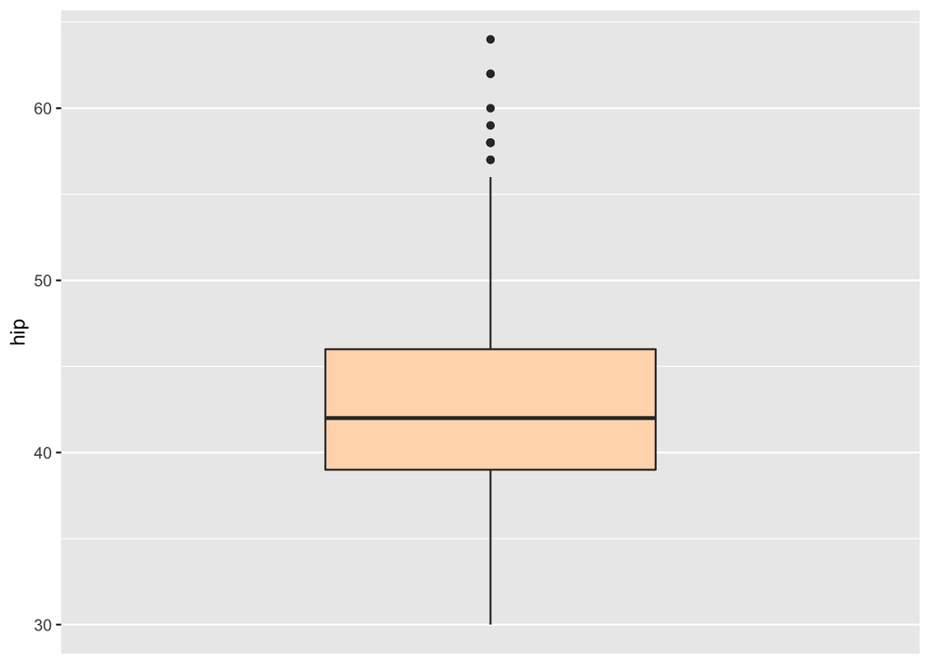

```r
ggplot(data = chlstrl) +
  scale_x_discrete(breaks = c()) +
  geom_boxplot(mapping = aes(y = hip), fill = "peachpuff")
```

+Información sobre el variables categóricas

```r
chlstrl$gender = factor(chlstrl$gender)
```

Tabla de frecuencias absolutas según el genero

```r
chlstrl %>%
  count(gender)
```

```
## # A tibble: 2 × 2
##   gender     n
##   <fct>  <int>
## 1 female   234
## 2 male     169
```

Tabla de frecuencias relativas según genero

```r
chlstrl %>%
    count(gender) %>%
    mutate(gender, relFreq = prop.table(n), n=NULL)
```

```
## # A tibble: 2 × 2
##   gender relFreq
##   <fct>    <dbl>
## 1 female   0.581
## 2 male     0.419
```

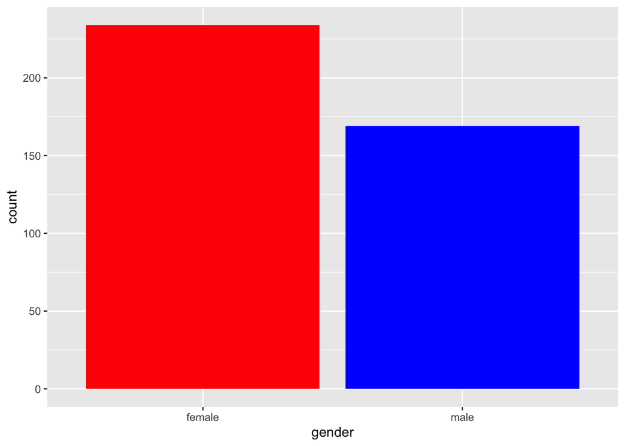

```r
ggplot(chlstrl) +
  geom_bar(mapping = aes(x = gender), fill=c("red","blue"))
```

- Los valores de `height` y `weight` están en pulgadas (inches) y libras (pounds) respectivamente. Una libra son $\approx$ 0.454kg y una pulgada son $\approx$ 0.0254m. Usa dplyr para convertir esas columnas a metros y kilogramos respectivamente. Las nuevas columnas deben llamarse igual que las originales.

```r
chlstrl %>%
  mutate(height=height*0.0254,weight=weight*0.454)
```

```
## # A tibble: 403 × 7
##     chol   age gender height weight waist   hip
##    <dbl> <dbl> <fct>   <dbl>  <dbl> <dbl> <dbl>
##  1   203    46 female   1.57   54.9    29    38
##  2   165    29 female   1.63   99.0    46    48
##  3   228    58 female   1.55  116.     49    57
##  4    78    67 male     1.70   54.0    33    38
##  5   249    64 male     1.73   83.1    44    41
##  6   248    34 male     1.80   86.3    36    42
##  7   195    30 male     1.75   86.7    46    49
##  8   227    37 male     1.50   77.2    34    39
##  9   177    45 male     1.75   75.4    34    40
## 10   263    55 female   1.60   91.7    45    50
## # … with 393 more rows
```

```r
(chlstrl <- chlstrl %>%
  mutate(BMI=weight/height^2))
```

```
## # A tibble: 403 × 8
##     chol   age gender height weight waist   hip    BMI
##    <dbl> <dbl> <fct>   <dbl>  <dbl> <dbl> <dbl>  <dbl>
##  1   203    46 female     62    121    29    38 0.0315
##  2   165    29 female     64    218    46    48 0.0532
##  3   228    58 female     61    256    49    57 0.0688
##  4    78    67 male       67    119    33    38 0.0265
##  5   249    64 male       68    183    44    41 0.0396
##  6   248    34 male       71    190    36    42 0.0377
##  7   195    30 male       69    191    46    49 0.0401
##  8   227    37 male       59    170    34    39 0.0488
##  9   177    45 male       69    166    34    40 0.0349
## 10   263    55 female     63    202    45    50 0.0509
## # … with 393 more rows
```

- Crea una nueva columna llamada `ageGroup` dividiendo la edad en los siguientes tres niveles:

```
(10,40], (40,70], (70,100]
```

```r
(chlstrl <- chlstrl %>%
  mutate(ageGroup = cut(age,breaks = c(10,40,70,100))))
```

```
## # A tibble: 403 × 9
##     chol   age gender height weight waist   hip    BMI ageGroup
##    <dbl> <dbl> <fct>   <dbl>  <dbl> <dbl> <dbl>  <dbl> <fct>
##  1   203    46 female     62    121    29    38 0.0315 (40,70]
##  2   165    29 female     64    218    46    48 0.0532 (10,40]
##  3   228    58 female     61    256    49    57 0.0688 (40,70]
##  4    78    67 male       67    119    33    38 0.0265 (40,70]
##  5   249    64 male       68    183    44    41 0.0396 (40,70]
##  6   248    34 male       71    190    36    42 0.0377 (10,40]
##  7   195    30 male       69    191    46    49 0.0401 (10,40]
##  8   227    37 male       59    170    34    39 0.0488 (10,40]
##  9   177    45 male       69    166    34    40 0.0349 (40,70]
## 10   263    55 female     63    202    45    50 0.0509 (40,70]
## # … with 393 more rows
```

```r
chlstrl %>%
  group_by(ageGroup) %>%
  filter(gender == "female") %>%
  summarise(mediaColesterol = mean(chol,na.rm=TRUE),mediaBMI = mean(BMI,na.rm=TRUE))
```

```
## # A tibble: 3 × 3
##   ageGroup mediaColesterol mediaBMI
##   <fct>              <dbl>    <dbl>
## 1 (10,40]             189.   0.0433
## 2 (40,70]             221.   0.0430
## 3 (70,100]            230.   0.0417
```

## Ejercicio 2: Funciones de R.

- Crea una función de R llamada `cambiosSigno` que dado un vector `x` de números enteros no nulos, como el siguiente vector:

  ```
  -12,  -19,  9,  -13,  -14,  -17,  8,  -19,  -14,
  ```

- Calcule cuántos cambios de signo ha habido. Es decir, cuántas veces el signo de un elemento es distinto del signo del elemento previo. Por ejemplo, en el vector anterior hay 4 cambios de signo (en las posiciones 3, 4, 7 y 8).

```r
cambiosSigno <- function(x,index=0){
  for (i in 2:length(x)){
    if (x[i]*x[i-1]<0) {
      index=index+1
    }
  }
  return(index)
}
cambiosSigno(x)
```

```
## [1] 4
```

- Modifica la función para que devuelva como resultado las posiciones donde hay cambios de signo. Llama `cambiosSignoPos(x)` a esa otra función. Por ejemplo, para el vector anterior el resultado de esta función sería [1] 3 4 7 8

```r
cambiosSignoPos <- function(x,cambioSig=c()){
  for (i in 2:length(x)){
    if (x[i]*x[i-1]<0) {
      cambioSig = append(cambioSig,i)
    }
  }
  return(cambioSig)
}
cambiosSignoPos(x)
```

```
## [1] 3 4 7 8
```

- También se valorará que incluyas en el código como usar `sample` para generar vectores aleatorios de 20 enteros *no nulos* (el vector debe poder tomar valores positivos y negativos).

```r
(vector=sample(c(-10:-1,1:10),20,replace=TRUE))
```

```
##  [1]  -3  -8  10   5  -6  -8  -7  -6 -10   4  -4  -5  -5   7   6  -5  -6   7  -5
## [20]   5
```

```r
cambiosSigno(x=vector)
```

```
## [1] 9
```

```r
cambiosSignoPos(x=vector)
```

```
## [1]  3  5 10 11 14 16 18 19 20
```

## Ejercicio 3. R4DS.

Es recomendable que esta semana del curso hagas al menos una lectura somera de los Capítulos 1 a 5 de [R for Data Science (R4DS), de H. Wickham](https://r4ds.had.co.nz/index.html), con énfasis especial en los Capítulos 3 y 5 (los capítulos 1, 2 y 4 son muy breves). Los siguientes apartados pretenden motivar esa lectura y por eso mismo pueden resultar un poco más laboriosos.

- Haz el [ejercicio 6 de la Sección 3.6.1 de R4DS](https://r4ds.had.co.nz/data-visualisation.html#exercises-3).

Prerequisitos:

```r
library(tidyverse)
library(ggplot2)
```

- Recreate the R code necessary to generate the following graphs.

Gráfica 1

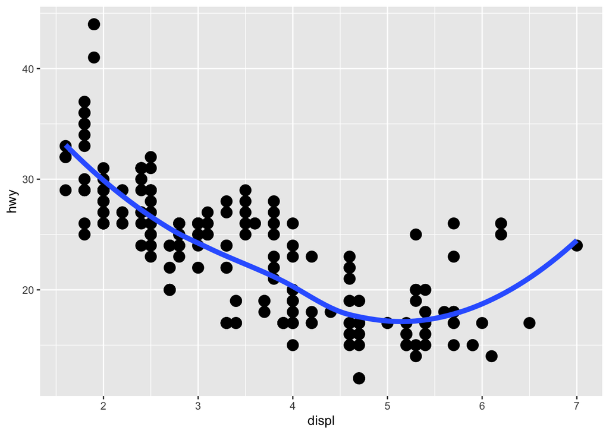

```r
(graph1 <- ggplot(data = mpg, mapping = aes(x = displ, y = hwy)) +
  geom_point(size=4) +
  geom_smooth(fill = NA,size=2))
```

Gráfica 2

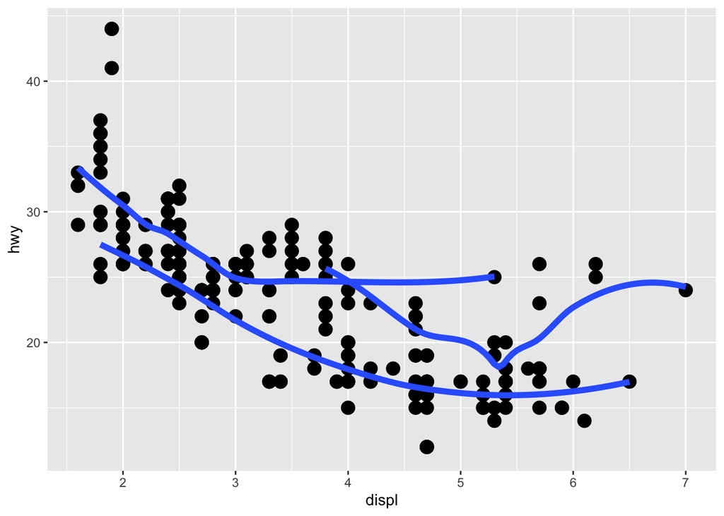

```r
(graph2 <- ggplot(data = mpg, mapping = aes(x = displ, y = hwy)) +
  geom_point(size=4) +
  geom_smooth(mapping = aes(group=drv),fill = NA,size=2))
```

Gráfica 3

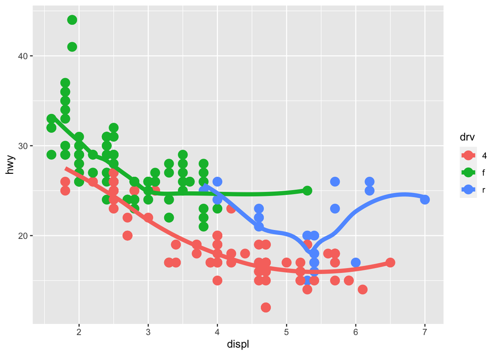

```r
(graph3 <- ggplot(data = mpg, mapping = aes(x = displ, y = hwy)) +
  geom_point(mapping = aes(color = drv), size=4) +
  geom_smooth(mapping = aes(color=drv),fill = NA,size=2))
```

Gráfica 4

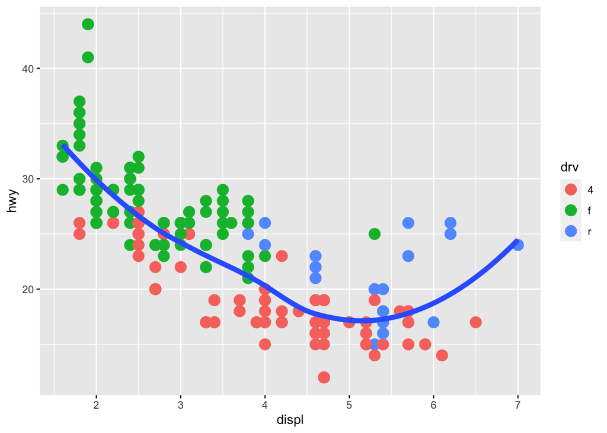

```r
(graph4 <- ggplot(data = mpg, mapping = aes(x = displ, y = hwy)) +
  geom_point(mapping = aes(color = drv), size=4) +
  geom_smooth(fill = NA,size=2))
```

Gráfica 5

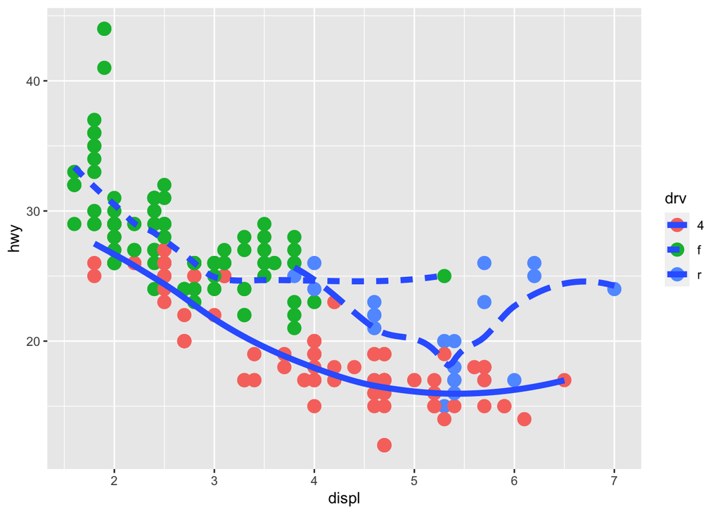

```r
(graph5 <- ggplot(data = mpg, mapping = aes(x = displ, y = hwy)) +
  geom_point(mapping = aes(color = drv), size=4) +
  geom_smooth(mapping = aes(group=drv,linetype = drv),fill = NA,size=2))
```

Gráfica 6

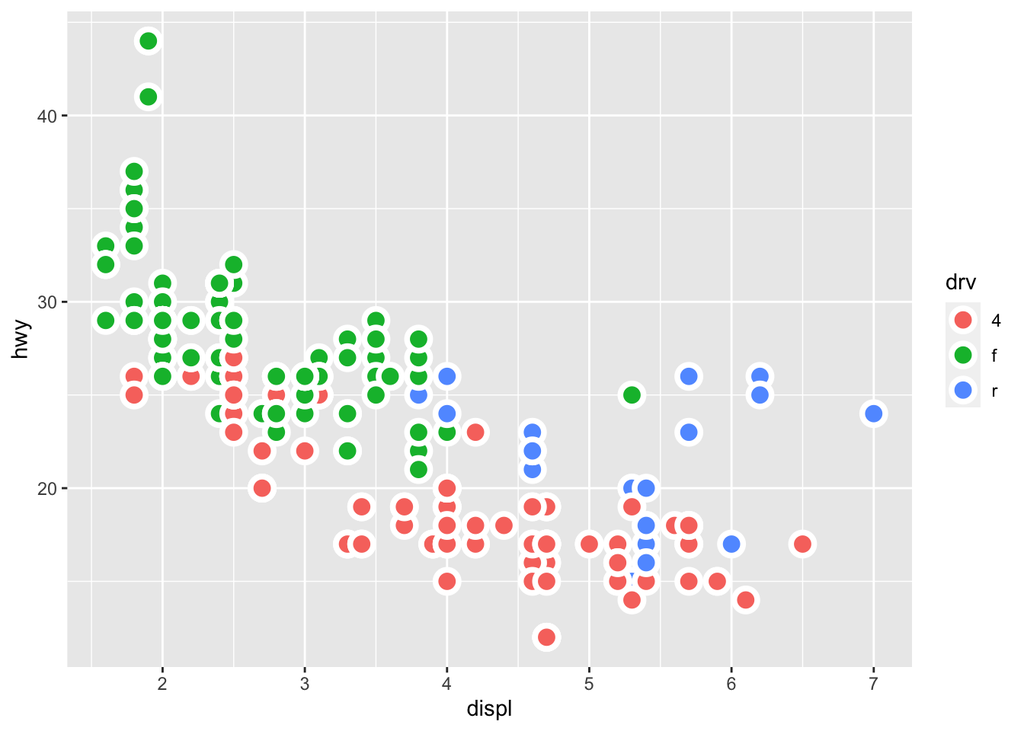

```r
(graph6 <- ggplot(data = mpg, mapping = aes(x = displ, y = hwy, color = drv, size=3)) +
  geom_point(mapping = aes(fill = drv), size=4, shape=21, col = "white", stroke = 2))
```

- Haz el [ejercicio 1 de la Sección 5.2.4 de R4DS](https://r4ds.had.co.nz/transform.html#exercises-8). Prerequisitos

```r
library(nycflights13)
```

### Find all flights that:

```r
flights %>%
  filter(dep_delay>=120)
```

```
## # A tibble: 9,888 × 19
##     year month   day dep_time sched_dep_time dep_delay arr_time sched_arr_time
##    <int> <int> <int>    <int>          <int>     <dbl>    <int>          <int>
##  1  2013     1     1      848           1835       853     1001           1950
##  2  2013     1     1      957            733       144     1056            853
##  3  2013     1     1     1114            900       134     1447           1222
##  4  2013     1     1     1540           1338       122     2020           1825
##  5  2013     1     1     1815           1325       290     2120           1542
##  6  2013     1     1     1842           1422       260     1958           1535
##  7  2013     1     1     1856           1645       131     2212           2005
##  8  2013     1     1     1934           1725       129     2126           1855
##  9  2013     1     1     1938           1703       155     2109           1823
## 10  2013     1     1     1942           1705       157     2124           1830
## # … with 9,878 more rows, and 11 more variables: arr_delay <dbl>,
## #   carrier <chr>, flight <int>, tailnum <chr>, origin <chr>, dest <chr>,
## #   air_time <dbl>, distance <dbl>, hour <dbl>, minute <dbl>, time_hour <dttm>
```

2. Flew to Houston (IAH or HOU)

```r
flights %>%
  filter(dest=='IAH'|dest=='HOU')
```

```
## # A tibble: 9,313 × 19
##     year month   day dep_time sched_dep_time dep_delay arr_time sched_arr_time
##    <int> <int> <int>    <int>          <int>     <dbl>    <int>          <int>
##  1  2013     1     1      517            515         2      830            819
##  2  2013     1     1      533            529         4      850            830
##  3  2013     1     1      623            627        -4      933            932
##  4  2013     1     1      728            732        -4     1041           1038
##  5  2013     1     1      739            739         0     1104           1038
##  6  2013     1     1      908            908         0     1228           1219
##  7  2013     1     1     1028           1026         2     1350           1339
##  8  2013     1     1     1044           1045        -1     1352           1351
##  9  2013     1     1     1114            900       134     1447           1222
## 10  2013     1     1     1205           1200         5     1503           1505
## # … with 9,303 more rows, and 11 more variables: arr_delay <dbl>,
## #   carrier <chr>, flight <int>, tailnum <chr>, origin <chr>, dest <chr>,
## #   air_time <dbl>, distance <dbl>, hour <dbl>, minute <dbl>, time_hour <dttm>
```

3. Were operated by United, American, or Delta

```r
flights %>%
  filter(carrier=='UA'|carrier=='DL'|carrier=='AA')
```

```
## # A tibble: 139,504 × 19
##     year month   day dep_time sched_dep_time dep_delay arr_time sched_arr_time
##    <int> <int> <int>    <int>          <int>     <dbl>    <int>          <int>
##  1  2013     1     1      517            515         2      830            819
##  2  2013     1     1      533            529         4      850            830
##  3  2013     1     1      542            540         2      923            850
##  4  2013     1     1      554            600        -6      812            837
##  5  2013     1     1      554            558        -4      740            728
##  6  2013     1     1      558            600        -2      753            745
##  7  2013     1     1      558            600        -2      924            917
##  8  2013     1     1      558            600        -2      923            937
##  9  2013     1     1      559            600        -1      941            910
## 10  2013     1     1      559            600        -1      854            902
## # … with 139,494 more rows, and 11 more variables: arr_delay <dbl>,
## #   carrier <chr>, flight <int>, tailnum <chr>, origin <chr>, dest <chr>,
## #   air_time <dbl>, distance <dbl>, hour <dbl>, minute <dbl>, time_hour <dttm>
```

4. Departed in summer (July, August, and September)

```r
flights %>%
  filter(month==7|month==8|month==9)
```

```
## # A tibble: 86,326 × 19
##     year month   day dep_time sched_dep_time dep_delay arr_time sched_arr_time
##    <int> <int> <int>    <int>          <int>     <dbl>    <int>          <int>
##  1  2013     7     1        1           2029       212      236           2359
##  2  2013     7     1        2           2359         3      344            344
##  3  2013     7     1       29           2245       104      151              1
##  4  2013     7     1       43           2130       193      322             14
##  5  2013     7     1       44           2150       174      300            100
##  6  2013     7     1       46           2051       235      304           2358
##  7  2013     7     1       48           2001       287      308           2305
##  8  2013     7     1       58           2155       183      335             43
##  9  2013     7     1      100           2146       194      327             30
## 10  2013     7     1      100           2245       135      337            135
## # … with 86,316 more rows, and 11 more variables: arr_delay <dbl>,
## #   carrier <chr>, flight <int>, tailnum <chr>, origin <chr>, dest <chr>,
## #   air_time <dbl>, distance <dbl>, hour <dbl>, minute <dbl>, time_hour <dttm>
```

```r
flights %>%
  filter(dep_time==sched_dep_time|arr_delay>120)
```

```
## # A tibble: 26,545 × 19
##     year month   day dep_time sched_dep_time dep_delay arr_time sched_arr_time
##    <int> <int> <int>    <int>          <int>     <dbl>    <int>          <int>
##  1  2013     1     1      559            559         0      702            706
##  2  2013     1     1      600            600         0      851            858
##  3  2013     1     1      600            600         0      837            825
##  4  2013     1     1      607            607         0      858            915
##  5  2013     1     1      615            615         0     1039           1100
##  6  2013     1     1      615            615         0      833            842
##  7  2013     1     1      635            635         0     1028            940
##  8  2013     1     1      655            655         0     1021           1030
##  9  2013     1     1      739            739         0     1104           1038
## 10  2013     1     1      745            745         0     1135           1125
## # … with 26,535 more rows, and 11 more variables: arr_delay <dbl>,
## #   carrier <chr>, flight <int>, tailnum <chr>, origin <chr>, dest <chr>,
## #   air_time <dbl>, distance <dbl>, hour <dbl>, minute <dbl>, time_hour <dttm>
```

```r
flights %>%
  filter((dep_delay-arr_delay)>30|dep_delay>=60)
```

```
## # A tibble: 43,165 × 19
##     year month   day dep_time sched_dep_time dep_delay arr_time sched_arr_time
##    <int> <int> <int>    <int>          <int>     <dbl>    <int>          <int>
##  1  2013     1     1      701            700         1     1123           1154
##  2  2013     1     1      811            630       101     1047            830
##  3  2013     1     1      820            820         0     1249           1329
##  4  2013     1     1      826            715        71     1136           1045
##  5  2013     1     1      840            845        -5     1311           1350
##  6  2013     1     1      848           1835       853     1001           1950
##  7  2013     1     1      857            851         6     1157           1222
##  8  2013     1     1      909            810        59     1331           1315
##  9  2013     1     1      957            733       144     1056            853
## 10  2013     1     1     1025            951        34     1258           1302
## # … with 43,155 more rows, and 11 more variables: arr_delay <dbl>,
## #   carrier <chr>, flight <int>, tailnum <chr>, origin <chr>, dest <chr>,
## #   air_time <dbl>, distance <dbl>, hour <dbl>, minute <dbl>, time_hour <dttm>
```

7. Departed between midnight and 6am (inclusive)

```r
flights %>%
  filter(between(hour,0,6))
```

```
## # A tibble: 27,905 × 19
##     year month   day dep_time sched_dep_time dep_delay arr_time sched_arr_time
##    <int> <int> <int>    <int>          <int>     <dbl>    <int>          <int>
##  1  2013     1     1      517            515         2      830            819
##  2  2013     1     1      533            529         4      850            830
##  3  2013     1     1      542            540         2      923            850
##  4  2013     1     1      544            545        -1     1004           1022
##  5  2013     1     1      554            600        -6      812            837
##  6  2013     1     1      554            558        -4      740            728
##  7  2013     1     1      555            600        -5      913            854
##  8  2013     1     1      557            600        -3      709            723
##  9  2013     1     1      557            600        -3      838            846
## 10  2013     1     1      558            600        -2      753            745
## # … with 27,895 more rows, and 11 more variables: arr_delay <dbl>,
## #   carrier <chr>, flight <int>, tailnum <chr>, origin <chr>, dest <chr>,
## #   air_time <dbl>, distance <dbl>, hour <dbl>, minute <dbl>, time_hour <dttm>
```